# Novel biogeographic patterns across latitudinal and elevational gradients: A case study with tropical montane epiphytes lends insights to conservation - Hollenbeck - - Journal of Biogeography - Wiley 

[Journal of Biogeography](https://onlinelibrary.wiley.com/journal/13652699)

[Early View](https://onlinelibrary.wiley.com/toc/13652699/0/0)

RESEARCH ARTICLE

Full Access

# Novel biogeographic patterns across latitudinal and elevational gradients: A case study with tropical montane epiphytes lends insights to conservation

[Emily C. Hollenbeck](https://onlinelibrary.wiley.com/action/doSearch?ContribAuthorStored=Hollenbeck%2C+Emily+C)

[Dov F. Sax](https://onlinelibrary.wiley.com/action/doSearch?ContribAuthorStored=Sax%2C+Dov+F)

First published: 12 February 2021

https://doi.org/10.1111/jbi.14059

Handling Editor: Richard Ladle

## Abstract

### Aim

While latitudinal and elevational gradients of range size have been thoroughly studied, the ways these gradients might interact with each other to shape species distributions in complex montane environments are not well understood. We examined how elevational and latitudinal gradients interact to structure individual species’ distributions and larger geographic range size patterns.

### Location

Neotropics.

### Taxa

Two epiphytic plant genera: *Peperomia* and *Elaphoglossum*.

### Methods

We compiled 35,382 GBIF records for 505 species, calculated species’ latitudinal and elevational range extents, and examined gradients in richness and range size. For individual species, we analysed the relationship between elevational and latitudinal occurrences.

### Results

Approximately 50% of species demonstrate a significant, negative relationship between their elevational and latitudinal occurrences; most of these species occupy a non‐random, relatively narrow range of mean annual temperatures across their latitudinal distribution. Across species there is a positive relationship between latitudinal and elevational extent, a phenomenon we hereafter refer to as ‘Stevens’ pattern’. Average latitudinal extent of species’ ranges increased at higher latitudes, in support of Rapoport's rule. Average elevational extent increased with elevation in the global dataset (consistent with Rapoport's elevational rule), but most subsets of the data demonstrated a peak in average extent size at mid‐elevations.

### Main conclusions

The prevalence of species with negative elevation‐by‐latitude relationships, along with their non‐random tracking of temperature, suggests that many tropical species with broad geographic distributions are more temperature sensitive than their broad ranges might otherwise suggest. Consequently, even tropical species that occur across a wide range of latitudes and elevations might be threatened by climate change. These wide‐ranging species drive the occurrence of two biogeographic patterns: Rapoport's elevational rule and Stevens’ pattern. Finally, while Rapoport's rule and its elevational corollary were supported in part, the unexpected occurrence of many species restricted to high elevations near the equator suggests a possible focus for conservation effort.

## 1 INTRODUCTION

Variation in species’ range limits along environmental gradients yields emergent patterns in species richness and geographic range size (Lomolino et al., 2010). Range size has been measured in multiple dimensions, with regard to elevational extent or latitudinal extent, and although range size relative to gradients of both latitude and elevation have received attention in the literature (Blackburn & Ruggiero, 2001; Chan et al., 2016; Colwell et al., 2008; Kluge et al., 2006; McCain, 2006; Sanders, 2002; Stevens, 1989, 1992), how the intersection of these two gradients might influence the structure of species’ distributions is not well understood (Halbritter et al., 2013; Ruggiero & Lawton, 1998; Sheldon et al., 2015, 2018). Temperature gradients across both latitudinal and elevational clines may limit individual species’ distributions on their own (Garcia‐Robledo et al., 2016; Smith, 2012) or, perhaps, in concert with each other. For example, a terrestrial species found at high elevations near the equator might be restricted to low elevation sites at higher latitudes, where conditions are colder, on average, for a given elevation. The basic relationship between temperature gradients and species’ temperature tolerances leads to an expectation that species should show a negative relationship between their latitudinal and elevational occurrences, that is, a ‘negative elevation‐by‐latitude’ distributional pattern, which should result in a species remaining within a relatively constant temperature range across latitude. A classic example occurs at tree line, which reaches higher elevations at lower latitudes (Humboldt, 1817; Korner, 1998; Randin et al., 2013). Anecdotal examples of such patterns have been observed within tree species and communities such as oak woodlands, Douglas fir and red spruce (Johnson et al., 2019; White & Cogbill, 1992), creating an impression that such patterns should be general, or are well documented. However, despite being oft‐repeated and apparently well‐known, empirical characterization of these anecdotal examples remains elusive in the primary literature (but see Randin et al., 2013; White & Cogbill, 1992), so the prevalence of such relationships on a broader scale remains unexplored. It is also unclear whether negative elevation‐by‐latitude relationships will emerge when considering species’ entire distributions, or instead whether such patterns are most apparent along range edges, for example, among the highest or lowest elevation points at any given latitude, for example, as with elevational tree line (Randin et al., 2013). Evidence for how such patterns manifest could be informative for other biogeographic phenomena, might help to identify species whose distributions are in equilibrium with climate, and could indicate species that will be sensitive to changes in temperature despite having broad latitudinal and elevational ranges.

If the same types of climatic factors limit the latitudinal and elevational limits of species (Halbritter et al., 2013; Randin et al., 2013), then across larger regions with extensive topographic relief, species should show a positive correlation between latitudinal extent and elevational extent. Such a relationship has occasionally been mentioned in the literature. For example, 14 species of North American pines were shown to have a positive correlation between the ranked positions of their latitudinal and elevational extents (Pielou, 1979, p. 218). Likewise, a positive correlation between latitudinal and elevational extents of birds in South America is reported by Blackburn and Ruggiero (2001), and Stevens (1992) plotted a similar positive trend for mean elevational extent and binned latitudinal extents of bird species native to Venezuela. These empirical patterns hint at a common effect of these two climatic gradients on range size, but the potential generality of such a relationship, and whether it could inform our understanding of other biogeographic phenomena, has not been evaluated.

Rapoport's rule and the elevational corollary of Rapoport's rule describe empirical patterns in which, respectively, the average latitudinal extent of species decreases with decreasing latitude, and average elevational extent decreases with decreasing elevation (Stevens, 1989, 1992). Both patterns have mixed support in the literature. Rapoport's rule has been upheld for a variety of taxonomic groups in North America (Blackburn & Gaston, 1996; Gaston et al., 1998; Rapoport, 1975; Stevens, 1989, 1992), but was not supported in some studies (Rohde, et al., 1993; Roy, et al., 1994), and has primarily been evaluated across temperate latitudes, with only limited analysis within the tropics (Gaston, et al., 1998; Price et al., 1997; Rohde, 1996; Sizling et al., 2009; Tomasovych et al., 2015). Some have suggested that there may be fundamental differences in distribution patterns and the mechanisms causing them between the tropics and the temperate zone (Gaston & Chown, 1999; Khaliq et al., 2017). A meta‐analysis of evidence for elevational Rapoport's rule among vertebrates found support for the pattern in only 40% of 160 elevational gradients (McCain & Knight, 2013). One mechanism proposed for the patterns, the climatic variability hypothesis, states that large geographic extents are facilitated by broader climatic tolerances at high latitudes or elevations, which experience greater climatic variability (Chan et al., 2016; Janzen, 1967; Qian et al., 2017; Stevens, 1989). Geometric constraints on species range size within a bounded domain, such as the ‘mid‐domain effect’, might also explain these range size gradients in some circumstances (Colwell et al., 2016; Colwell & Hurtt, 1994; Colwell & Lees, 2000). However, it is also conceivable that these patterns are influenced by a relationship between species’ latitudinal and elevational distributions—an outcome that would not be obvious from examining either gradient alone. One way such an effect could manifest would be if Rapoport's range size patterns are driven by a subset of species that have negative latitude‐by‐elevation distributions. In this case, the emergence of Rapoport's rule or elevational rule could be driven by species with relatively narrow climatic tolerances that achieve a large distributional extent by tracking climate conditions across latitudinal and elevational space. This would suggest that the mechanism for both of Rapoport's rules would be just the opposite of the mechanism originally proposed (broad environmental tolerance). It would, however, be consistent with more general conjecture that species with narrow environmental tolerances can achieve large geographic extents when suitable environmental conditions occur across a large geographic area (Gaston & Chown, 1999; Tomasovych et al., 2015).

Characterizing distribution patterns that emerge at the intersection of latitudinal and elevational gradients would be most informative in a geographic setting with substantial, continuous elevational relief across a broad extent of latitude. The tropical and subtropical regions of North and South America are well suited for such a study. This region contains a large, relatively contiguous span of mountains with extensive elevational relief, spans both sides of the equator, and contains high species and taxonomic diversity, facilitating a search for general patterns. Within this region, we focus on epiphytic plants, which are most diverse in montane regions (Gentry & Dodson, 1987), sensitive to climate (Benzing, 1998; Gotsch et al., 2018; Nadkarni & Solano, 2002; Zotz & Bader, 2009), and hence are likely to provide significant variation in distributions across elevational gradients. Some of the most diverse and well‐known epiphyte groups, like orchids and bromeliads, are notoriously difficult to identify without flowers and hence are less likely to be well represented accurately in herbarium databases. Instead, genera like *Elaphoglossum* and *Peperomia*, which are rich in species throughout the Neotropics and can often be identified vegetatively (Frenzke et al., 2015; Matos & Moran, 2017), are better suited to this type of investigation.

We examined the elevational and latitudinal distributions of 244 *Elaphoglossum* and 261 *Peperomia* species in North and South America. We used expert knowledge of these two genera to help curate occurrence records from the Global Biodiversity Information Facility (GBIF), which were then used to examine individual species’ distribution patterns as well as calculate range metrics for all species. We measured the elevation‐by‐latitude relationships of individual species’ distributions, searched for interactions between gradients of elevation and latitude in structuring the assemblage of range sizes, used those new insights to reframe a series of classic gradients in a tropical montane system, and finally consider the conservation implications of these findings.

## 2 MATERIALS AND METHODS

### 2.1 Data and regional context

Occurrence records for all species of *Elaphoglossum* and *Peperomia*, bounded by 30°N–40°S latitude and 40°–120°W longitude, were downloaded on 21 September 2016 from GBIF using the ‘gbif’ function in the R package dismo (GBIF.org, 2016; Hijmans et al., 2017; R Core Team, 2016). Although these species are primarily restricted to tropical forests, we wanted to capture the entire geographic extents of these species (within the Western hemisphere), which occasionally extend into extratropical latitudes. Georeferenced records identified to species level were included, and elevation was included with these records when supplied by GBIF. After curation to remove incorrect records (See Appendix S1), we restricted the dataset to species with at least 10 elevation records. The final dataset consisted of 244 *Elaphoglossum* and 261 *Peperomia* species, with a total of 35,382 records, 27,843 of which included elevation.

The data were examined overall, separately by genus, and partitioned into subsets in three distinct ways. The first type of partition was by geographic region: once by hemisphere (split at the equator), and separately by continent (split at the border between Panama and Colombia). Records from the Caribbean islands were included in the subset split by hemisphere, but not within the continental subsets, since the latter intended to capture the biogeography within continuous continental landmasses. Second, the dataset was partitioned by 10‐degree bands of latitude from 40°S to 30°N, yielding seven data pools consisting exclusively of the occurrences in each latitudinal band (Figure 1). Elevational range metrics within each latitudinal band were recalculated considering only the records from that band. The occurrence threshold for inclusion in all geographically partitioned datasets was five elevational records per species, rather than 10 as in the entire dataset, because of the smaller geographic extents being considered. The third partition method split species according to their overall latitudinal extents, in 10‐degree bins of range size (0 to <10, 10 to <20, 20 to <30, etc.). Because these bins include all data available for each individual species, the standard applied to analysis of the entire dataset, that is, a minimum of 10 elevational records, was retained.

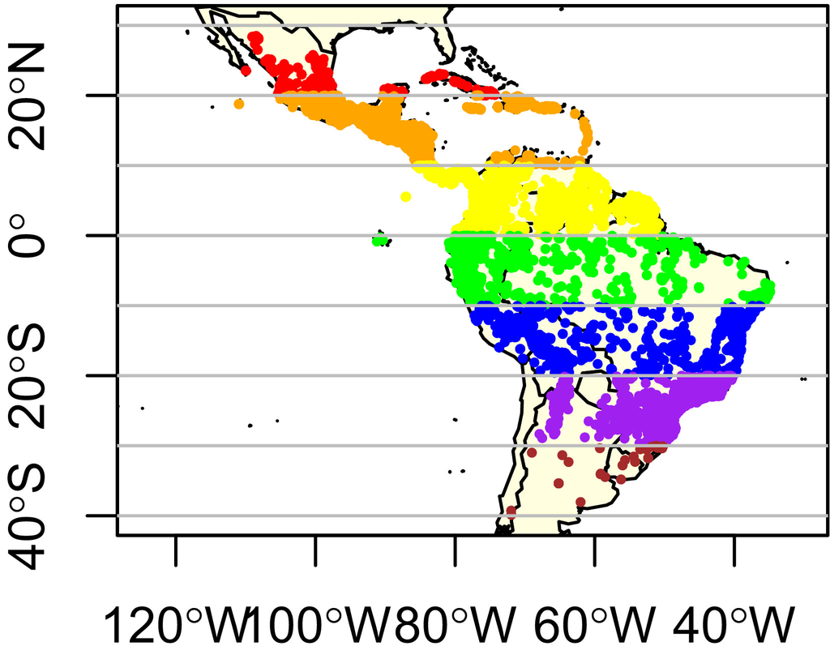

**FIGURE 1**

Open in figure viewer[PowerPoint](https://onlinelibrary.wiley.com/action/downloadFigures?id=jbi14059-fig-0001&doi=10.1111%2Fjbi.14059)

Dataset split into 10‐degree latitudinal bands. All occurrence records in the dataset are colour coded to indicate their assignment to a particular latitudinal band. For the analyses parsed by 10‐degree bands (Figure S8), only the records within an individual band were used for its respective set of calculations, for example, elevational extent and richness

Three temperature metrics from WorldClim were analysed across latitude and elevation in the Neotropics: mean annual temperature (bio1; ‘MAT’), maximum temperature of the warmest month (bio5; ‘max’) and minimum temperature of the coldest month (bio6; ‘min’). For pairing with species’ occurrence records and null model analyses, we used these bioclim variables at 2.5 arc‐minute resolution from WorldClim version 2 (Fick & Hijmans, 2017), and extracted the climate of the corresponding grid cell for each occurrence point (real and modelled). To illustrate how temperature varies across latitude within the tropics, we used the same variables at 10 arc‐minute resolution. We plotted the relationship between temperature and latitude within our study domain, at 1,000 m elevation intervals (Figure S1). For each elevational band, we selected all 10 arc‐minute grid cells between 40°S and 30°N within 10m of the target elevation. MAT, min and max were extracted from WorldClim version 1 (Hijmans et al., 2005) for each grid cell.

### 2.2 Analyses

#### 2.2.1 Elevation‐by‐latitude relationships for individual species

To determine if each individual species shifts its elevational range across latitude, the occurrence records of each species were compared to a null model representing the expectation of no response of occupied elevation to latitude. Only species with a latitudinal extent of at least 10° were considered for this analysis (313 species). The ordinary least‐squares (linear) regression between the elevation and absolute latitude of all occurrences of each species was compared against 1,000 randomly selected distributions unique for each species. The random null distributions were constrained to match the real number of occurrence records for each species, as well as maintaining the species’ measured elevational and latitudinal range limits, in order to account for the actual elevational space available at different latitudes. Null ‘occurrences’ were then sampled randomly from the environmental background within those limits. The slope of the regression of the real distribution data was compared to the slopes of the 1,000 null distributions for that species. If the slope of the real regression was more negative than 95% of the null slopes, that species was considered to have a significant negative relationship between elevation and latitude. Our statistical approach implicitly uses a one‐tailed test, of negative regression slopes, to test the significance of these relationships, as this provides the best test of our a priori hypothesis. Nonetheless, as a point of comparison, we also report the number of significantly positive relationships, using the same statistical approach.

Patterns of the temperature ranges that species occupy across latitude were examined with the same occurrence points and null distributions, in order to examine whether temperature constancy appeared in concert with elevational shifts. Mean annual, minimum and maximum temperature were extracted for all real and randomly selected points, and linear regressions calculated again for all real distributions and 1,000 null distributions for each species for each temperature variable across latitude. Since temperature generally declines with latitude (Figure S1), the null expectation generally yields a negative relationship between temperature and latitude, while if a species were tracking a more similar temperature niche across space than expected, the relationship would be flatter, or have a slope closer to zero. Thus, for temperature, a species is considered significant if its real slope is more positive than 95% of the null models.

#### 2.2.2 Range patterns across species assemblage

A suite of range metrics was calculated for all species. Latitudinal extent was calculated as the difference between the highest and lowest latitude where a species was recorded (irrespective of whether the range crosses the equator, so a range from 10°S to 10°N has an extent of 20°), and the midpoint between those extremes was the latitudinal midpoint (Figure 2a). Elevational extent was calculated as the difference between the highest and lowest elevation where the species was recorded from anywhere in its range, and the midpoint between those extremes was the elevational midpoint (Figure 2b).

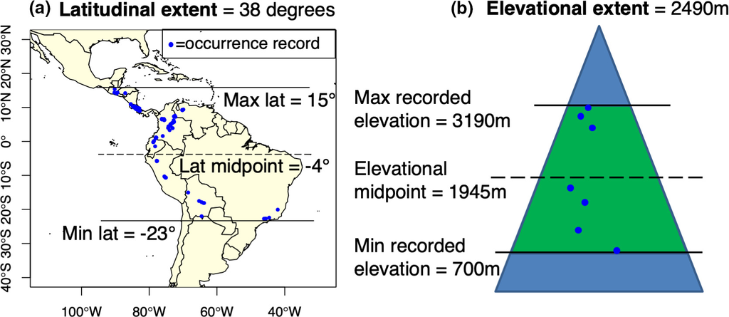

**FIGURE 2**

Open in figure viewer[PowerPoint](https://onlinelibrary.wiley.com/action/downloadFigures?id=jbi14059-fig-0002&doi=10.1111%2Fjbi.14059)

Illustration of the two main range metrics, latitudinal extent and elevational extent, for example species *Elaphoglossum eximium*. (a) Blue points map the locations of all the true occurrence records for *E. eximium*, illustrating the concept of latitudinal extent calculated from the maximum and minimum latitude at which the species was recorded. (b) Elevational extent is calculated in a similar way, with the maximum and minimum elevation for *E. eximium* shown using its known occurrence limits. The individual blue points in (b) are illustrative, not actual elevation records for this species

Gradients in range extent across latitude and elevation were examined with two methods used to assess Rapoport's rule: the Stevens method and the midpoint method (see Supporting information). In the Stevens method, each band of latitude (here, 5° bands) and elevation (here, 100 m bands) is considered separately; all species found in each band were identified, and the mean range extent for those species was calculated. Note that if a species had no records in a particular band, but its range extent spanned the band, it was considered present in that band (Stevens, 1989). This method enables qualitative description of range size patterns, but cannot be statistically tested, as the data points are not independent, for each point contains many of the same species as the points adjacent (Rohde et al., 1993; Stevens, 1989). Rapoport's rule patterns were examined for both latitudinal and elevational gradients, with the entire dataset and within genera. Elevational gradients were addressed again separately, within each latitudinal band, as well as each bin of latitudinal extent.

## 3 RESULTS

### 3.1 Elevation‐by‐latitude relationships for individual species

We found that 49% of the 313 species with latitudinal extents greater than 10° showed a significantly more negative relationship between their latitudinal and elevational occurrences than our null model, 16% of species had a positive relationship, and 35% of species had relationships within the null expectation (Figure 3). The relationships for each individual species are shown in Appendix S2. The impact of different significance thresholds on the per cent of species emerging as significant is shown in Table S1.

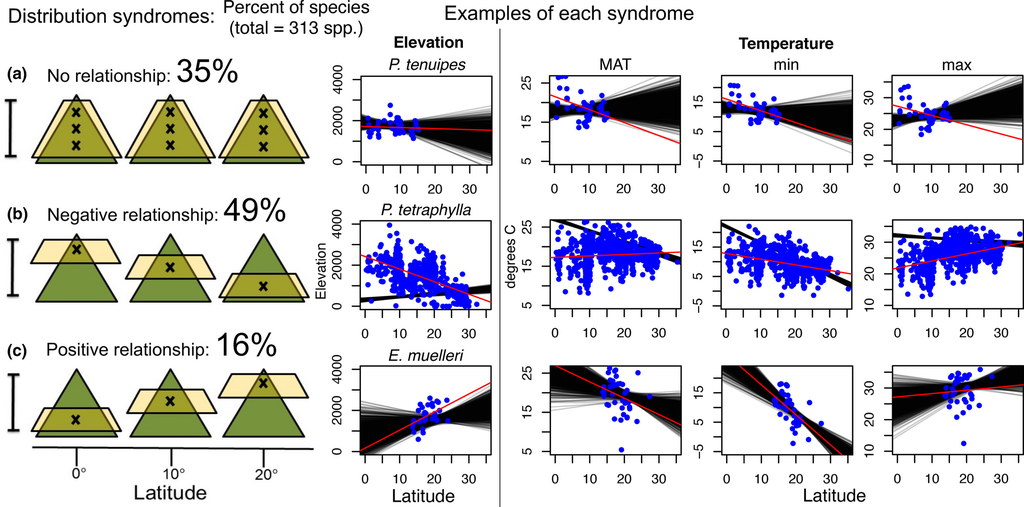

**FIGURE 3**

Open in figure viewer[PowerPoint](https://onlinelibrary.wiley.com/action/downloadFigures?id=jbi14059-fig-0003&doi=10.1111%2Fjbi.14059)

The majority of species, 62%, had temperature distributions across latitude that significantly differed from null model expectations, such that the slopes of their temperature‐by‐latitude relationships were closer to zero, that is, ‘flatter’, than expected by chance (Table S1). Most species that showed a significant elevation‐by‐latitude relationship also showed a significant temperature‐by‐latitude relationship (Table S1). There were, however, many species (20% of the total) that showed a significant temperature‐by‐latitude relationship, but not a significant elevation‐by‐latitude relationship (Table S1). The shape of null distributions as well as actual distributions varied substantially among species; we show all species elevation‐by‐latitude relationships in Appendix S2 to illustrate this variation (Figures S2–S4).

### 3.2 Relationship between latitudinal and elevational extent

There was a significant positive correlation between elevational and latitudinal extents of species across the entire dataset, in each continent, in each hemisphere and for each genus individually (Figure 4 and Figure S5). In the entire dataset and in each of the partitioned datasets, the majority of species had both small elevational extents and latitudinal extents, that is, had distributions in the bottom left quadrant of each panel (Figure 4 and Figure S5). Across all analysed taxa, the mean latitudinal extent was 18.6° and mean elevational extent was 1,929 m. Most of the species in the top right quadrant, those with the broadest latitudinal and elevational extents, had negative elevation‐by‐latitude relationships.

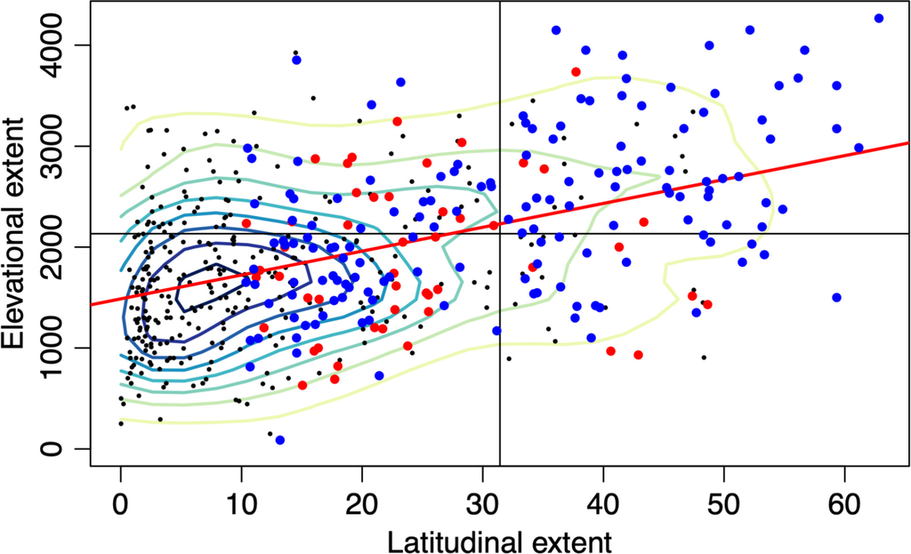

**FIGURE 4**

Open in figure viewer[PowerPoint](https://onlinelibrary.wiley.com/action/downloadFigures?id=jbi14059-fig-0004&doi=10.1111%2Fjbi.14059)

### 3.3 Rapoport's Rule

Patterns consistent with Rapoport's rule and the elevational corollary of Rapoport's rule, respectively, were found when considering the entire dataset, as average latitudinal extent increased with increasing latitude (Figure 5a) and average elevational extent increased with increasing elevation (Figure 5c). Richness gradients also fit expected patterns (Figure S6). However, when species with negative latitude‐by‐elevation relationships were removed, range size patterns consistent with the both elevational and latitudinal Rapoport's rule were no longer found. Mean latitudinal extent no longer increased with distance from the equator; the higher‐latitude bands now had lower mean extent, removing any consistent trend across latitude (Figure 5b). The pattern of elevational extent also changed qualitatively, such that average elevational extent displayed a unimodal trend, declining after a maximum in the band from 3,100 to 3,200 m a.s.l. (Figure 5d). When species in the two study genera were analysed separately, *Elaphoglossum* followed the global trend while *Peperomia* had a unimodal pattern with a decline in average elevational extent above 3,000 m (Figure S7).

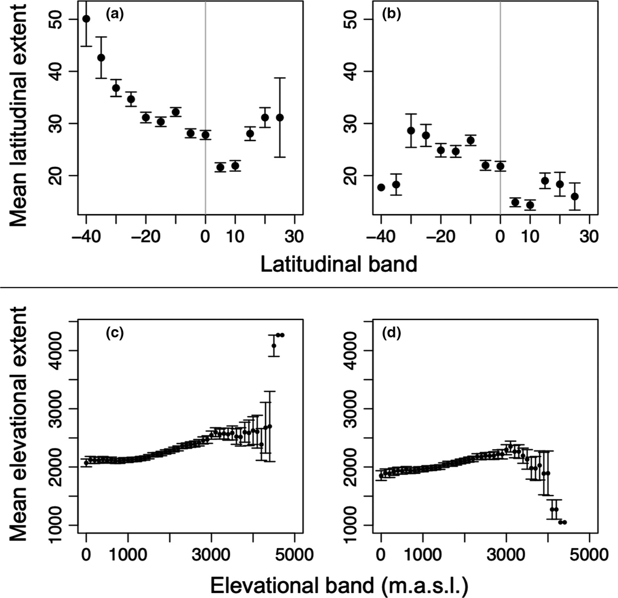

**FIGURE 5**

Open in figure viewer[PowerPoint](https://onlinelibrary.wiley.com/action/downloadFigures?id=jbi14059-fig-0005&doi=10.1111%2Fjbi.14059)

Species partitioned into groups based on their latitudinal extent sizes differed in several ways with respect to their elevational distribution patterns (Figure 6). Considering the species with smaller latitudinal extents, the trend of average elevational extent across elevation (calculated with the Stevens method) was unimodal, with average elevational extent increasing until a peak around 3,000 m a.s.l., after which it declined (Figure 6b–e). Only the two largest size classes, with the fewest species, yielded trends consistent with the elevational corollary of Rapoport's rule, monotonically increasing average elevational extent with increasing elevation (Figure 6f,g).

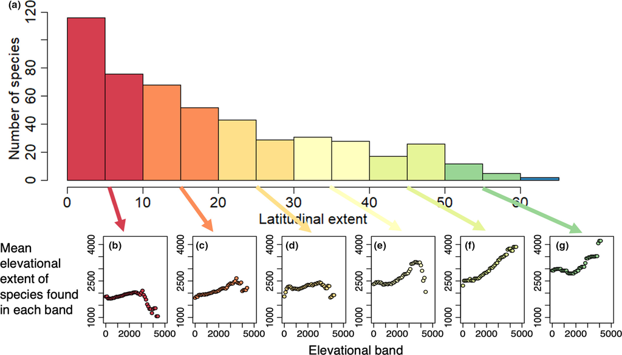

**FIGURE 6**

Open in figure viewer[PowerPoint](https://onlinelibrary.wiley.com/action/downloadFigures?id=jbi14059-fig-0006&doi=10.1111%2Fjbi.14059)

Distribution of latitudinal and elevational extents, and the elevational corollary of Rapoport's rule examined for each latitudinal extent size class. (a) Frequency of species binned by latitudinal extents. The seven latitudinal extent size classes (different colours) are split and all but the largest are analysed separately in (b–g): Mean elevational extent of all species found in each elevational band (Stevens method for examining Rapoport's rule). Note that axes have different scales. There were too few species in the largest size class to analyse a range size gradient (>60 degrees; *N* = 2)

When Rapoport's rule was examined within regions, represented by 10‐degree bands of latitude, patterns of elevational extent were qualitatively different in lower versus higher latitude bands. In the bands from 10 to 20°S, 20 to 30°S and 20 to 30°N, mean elevational extent increased monotonically with greatest extent at highest elevations (Figure S8c,e,f). In contrast, in the bands of 0–10°S, 0–10°N and 10–20°N, mean elevational extent was unimodal with a peak around 3,000 m a.s.l., followed by decreasing elevational extent at higher elevations (Figure S8a,b,d).

## 4 DISCUSSION

### 4.1 Elevation‐by‐latitude relationships for individual species

We show that many species have geographic distributions in which their occurrences display a negative elevation‐by‐latitude relationship, such that species occupy progressively lower elevations with increasing latitude. Most of the species with such relationships were also found to occupy a more stable temperature range across latitude than expected by chance, strongly suggesting that these species utilize the temperature gradients across both elevation and latitude in concert to remain within their temperature niche across broad geographic extents, that is, ‘tracking temperature’ to lower elevations at higher latitudes. This phenomenon occurs even in the tropics, where although the latitudinal temperature gradient is shallower than at higher latitudes (Colwell et al., 2008; Gaston & Chown, 1999), it is not negligible, and minimum temperature in particular has a distinct latitudinal gradient (Gaston & Chown, 1999; Figure S1). Even more species show significant relationships between temperature and latitude than between elevation and latitude. This indicates that a species can track its temperature niche in space without relying exclusively on elevational gradients, which is a more general assumption of climatic niche modelling, or alternatively that the data we analysed are too coarse‐grained to capture fine‐scale variation across steep topographic gradients.

We specifically examine the negative elevation‐by‐latitude relationships in this study in order to quantify and formalize this phenomenon that until now has largely been described qualitatively and anecdotally. Although shifts in elevational distributions with latitude are a logical outcome if species’ distributions are limited by temperature (e.g., Humboldt, 1817; Pielou, 1979), and although there is a long‐standing appreciation of changes in the elevational distribution of ecosystems across latitude (Humboldt, 1817; Lomolino et al., 2010; White & Cogbill, 1992), there has been little recent attention paid to this topic in the literature (e.g. Johnson et al., 2019; Randin et al., 2013), and no study to our knowledge has assessed this phenomenon with respect to species’ entire ranges, but instead tended to focus on extreme range edges, such as tree line. We also draw attention here to the fact that this phenomenon has important impacts on a number of other biogeographic patterns, such as Rapoport's rule, which we discuss below.

The prevalence of species with negative latitude‐by‐elevation relationships has important implications for understanding the factors that set range boundaries and for conservation. These relationships are particularly common among species with the broadest latitudinal and elevational extents (Figure 4), suggesting that the negative elevation‐by‐latitude relationship may be an important mechanism by which species achieve broad ranges. Of course, we are not the first to point out that broad ranges do not necessarily imply broad climatic tolerances (Gaston & Chown, 1999; Khaliq et al., 2017; Tomasovych et al., 2015). Still, the pattern we observe here means that some species with broad latitudinal ranges, particularly those that have relatively tight relationships between latitudinal and elevational occurrences, might be much more sensitive to temperature (and potential changes in temperature) than would be otherwise obvious, either from a coarse assessment of their geographic distribution or from typical climate niche modelling approaches, which can be difficult to parameterize adequately in montane tropical environments, where there are often complex climatic gradients, poorly suited to interpolation and relatively few high‐quality measures of climate. We also found that minimum temperature appears to influence more species than does maximum temperature, consistent with previous work indicating that range boundaries are more commonly climatically set by cold than by warm limits (e.g. Addo‐Bediako et al., 2000; Dvorsky et al., 2017; Gaston & Chown, 1999; Sunday et al., 2011). Ultimately, subtly different ways of examining temperature gradients and range limits, as well as different potential mechanisms for these patterns, suggest different ways that temperature can limit the distribution of species. For example, in addition to responding to temperature per se, other factors such as climatic variability may be at play in structuring species’ distributions. We hope that future work can more fully resolve the generality of these patterns and potential mechanisms for them by applying the types of analysis conducted here with additional taxonomic groups and regions.

There are several potential explanations for the fractions of species in our dataset that either did not show significant relationships with temperature or showed a positive elevation‐by‐latitude relationship. The species showing no relationship with temperature might have range boundaries that are set by other abiotic factors (such as moisture) or biotic interactions (such as pathogens or competition)—factors that might not vary as predictably with elevation and latitude. Positive elevation‐by‐latitude relationships could arise due to uneven sampling effort across a species’ distribution that causes spurious patterns to emerge, or in cases where a species tracks an environmental factor that happens to be found at higher elevations with increasing latitude. Both phenomena might also be explained by the presence of cryptic taxa that have different environmental requirements, by strong local adaptation of populations or by errors in identification of species.

### 4.2 A new biogeographic phenomenon: Stevens’ pattern

We found a positive correlation between species’ latitudinal and elevational extents. This relationship manifests when considering all occurrence data in aggregate, and also when data were split by continent, hemisphere or taxonomic group. Given the catalytic role George Stevens has played in driving the study of range size gradients (e.g. Stevens, 1989, 1992), his role as the first to show this type of pattern graphically, and our expectation that this positive correlation between elevational and latitudinal extent is likely to be repeated, we hereafter refer to this relationship as ‘Stevens’ pattern’. A similar trend has been described occasionally in the literature (Blackburn & Ruggiero, 2001; Pielou, 1979; Stevens, 1992), although not plotted in this way. One case where Stevens’ pattern was not supported was in an analysis of rodents of Costa Rica that used population level, as opposed to species‐wide, elevational extents (McCain, 2006). We believe that Stevens’ pattern should be found in other taxonomic groups in both tropical and extratropical regions whenever considering species’ global elevational extents.

Stevens’ pattern could result from several possible mechanisms. It could be driven by temperature sensitivity and the negative latitude‐by‐elevation relationships we describe, which are especially common in the very widest‐ranging species (Figure 4). We demonstrate that many of the widest‐ranging species broaden their global elevational range by occupying lower elevations at higher latitudes. This will tend to drive a positive relationship between latitudinal and elevational extent, since species constrained in this way, presumably by temperature, will occupy increasing total elevational extents with increasing latitudinal extents. Alternatively, this pattern could arise through the mechanisms described in Stevens’ original papers on Rapoport's rule (Stevens, 1989, 1992): if broader climatic tolerances allow species to occupy wider ranges, this should apply to both elevational and latitudinal gradients, causing range extent to correlate across these two dimensions. Consequently, Stevens’ pattern could conceivably manifest when broad‐ranging species have either wide climatic tolerances (allowing them to occupy a broad range of elevations and latitudes) or narrow climatic tolerances, so long as these species occur in a region with ample topographic relief and the species predominately exhibit negative elevation‐by‐latitude relationships. We believe that Stevens’ pattern should be observed whenever the global distribution of a taxonomic group is examined, at least so long as there is significant topographic relief across the distribution of these species. However, additional work is needed to substantiate this prediction, to determine if there are a common set of exceptions, and to understand the relative importance of the principal mechanisms driving the pattern.

### 4.3 Rapoport's rule

When considering species’ global range extents across the Neotropics, we found ostensible support for Rapoport's rule, such that mean latitudinal extent increased with latitude, and for Rapoport's elevational rule, such that mean elevational extent increased at higher elevations. While Rapoport's rule has been widely investigated, we provide one of the few tests of this pattern in a group restricted to the tropics, and we find that this pattern holds in the tropics of both North and South America. This is in contrast to recent work examining overall patterns in geographic range size of new world plants (Morueta‐Holme et al., 2013; Weiser et al., 2007), which did not support Rapoport's rule.

However, further analyses with partitioned datasets point to novel mechanisms for Rapoport's rule, which may fundamentally change our interpretation of Rapoport's rules and of range size gradients more generally. Unlike in the global dataset, when considering various subsets of the data, the evidence for Rapoport's rule disappeared, and in the case of Rapoport's elevational rule, even reversed direction (at high elevations). In both cases, we show that species with negative latitude‐by‐elevation relationships, particularly those with the very broadest ranges, drove the global manifestation of both of Rapoport's rules. Specifically, when the 152 species with significantly negative elevation‐by‐latitude relationships were removed, both latitudinal and elevational Rapoport patterns disappeared. First, there was no longer an increase in latitudinal extent at higher latitudes, and second, the pattern of mean elevational extent changed to a unimodal pattern, with average elevational range size declining after a peak at around 3,000 m (Figure 5). By definition, those species with negative elevation‐by‐latitude relationships do not occupy their entire broad range of elevations at any given latitude. Thus, the large elevational extents measured on average for species at higher elevations are misleading, because these species do not, in fact, tend to experience a broad range of elevational distributions within any particular band of latitude.

In some ways, our partitioned datasets are more analogous to regional studies or studies of individual elevational transects, where support for the elevational corollary of Rapoport's rule has been mixed (McCain & Knight, 2013; Stevens, 1992). It is important to note that the ‘reversal’ of Rapoport's rule that we detected at high elevations would be missed in regional or transect studies that do not sample above 3,000 m. Because the decline in elevational extent at high elevations appeared within the most diverse subsets of our data, that is, in low‐latitude regions and among smaller‐ranging species, we posit that this decline is a typical feature of low‐latitude mountaintop biogeography. Indeed, there are many species near the equator with small elevational extents, pointing to high conservation priority in these regions.

The mechanism originally proposed for the elevational corollary of Rapoport's rule hypothesized that species at higher elevations have broader elevational ranges due to broader climatic tolerances. We show that this mechanism is unlikely to be the primary driver of this pattern, because the high‐elevation species we examined tend to occupy a relatively narrow range of elevations wherever they occur. Instead, the pattern observed within our dataset appears to be driven by temperature‐sensitive species that nonetheless demonstrate broad global ranges by shifting downward in elevation with increasing latitude.

Ultimately, the patterns of species’ geographic range size across elevational gradients have potentially important implications for conservation. In contrast to the expected pattern, we found that species at the uppermost elevations more often had smaller elevational extents, especially near the equator. These low‐latitude, mountaintop‐restricted species may be at high extinction risk due to climate change. Our analysis suggests that many of them may have narrow temperature tolerances, and so they may be pushed upward in elevation in response to warming temperatures, but since they are already near the tops of mountains, they may have nowhere to go and be faced with extirpation (Colwell et al., 2008; La Sorte & Jetz, 2010; Ohlemüller et al., 2008).

## 5 SYNTHESIS AND CONCLUSIONS

We have identified three main biogeographic patterns in this tropical group: negative latitude‐by‐elevation relationships, Stevens’ pattern, and a reduction in mean elevational range size at high elevations. Together, these three patterns allow us to reach several important conclusions about how species’ ranges are structured by environmental gradients and climate. First, global range metrics can be misleading indicators of the breadth of species’ climatic tolerances, as species with broad ranges can still be temperature sensitive (Gaston & Chown, 1999; Tomasovych et al., 2015). Integrating data on species’ global and local or regional distributions is necessary in order to understand the relationship between their biogeography and climatic niche breadth. Second, there may be multiple ways to achieve broad ranges, and multiple mechanisms that could yield broad patterns such as Stevens’ rule and Rapoport's rule. Although some species with broad ranges truly have very broad climatic tolerances, we show that another common way to achieve broad latitudinal and elevational extents is by harnessing a negative latitude‐by‐elevation relationship to track a narrower climatic niche across mountainous regions. Finally, understanding how these phenomena interact gives us a window into which species and regions merit the most conservation focus. Narrow‐ranging species are intrinsically at higher risk of extinction (Murray et al., 2017; Ricketts et al., 2005), and we have identified predictable trends in the prevalence of species with narrow elevational ranges in the tropics: at high elevations, near the equator, and among species with narrow latitudinal distributions. Even among broadly distributed species, the prevalence of negative latitude‐by‐elevation relationships reveals a potential sensitivity to temperature changes throughout their ranges. If elevational ranges reflect climatic sensitivity, the high prevalence of narrow‐ranging species demonstrates high conservation risk due to climate change in tropical mountains. Further research to empirically measure the relationship between range limits and climatic limits will greatly aid conservation risk assessments in tropical mountains.

## ACKNOWLEDGEMENTS

We thank Robbin Moran, Fernando Matos, Alexander Rojas, and Guido Mathieu, who provided generous help learning the taxonomy of the study groups, and the New York Botanical Garden, which allowed access to their herbarium. We thank Emmaline Suchland, who explored some of the ideas addressed in this paper in her senior thesis. We thank Dr. Signe Normand and 2 anonymous reviewers for their useful comments. ECH has been supported by NSF Graduate Research Fellowship 1644760, as well as a Graduate Fellowship and research funding from the Institute at Brown for the Environment and Society (IBES). No research permits were needed for this study, as the data used are all publicly available from GBIF (https://www.gbif.org)

## CONFLICT OF INTEREST

The authors declare no conflict of interest.

## Open Research

## Supporting Information

## REFERENCES

## BIOSKETCH

**Emily C. Hollenbeck** seeks to forecast extinction risk from climate change in tropical montane forests. The aim of her research is to accurately characterize species’ climatic niches by pairing distribution information, particularly along elevational gradients, with precise field measurements and organism‐level understanding of cloud forest plants.

**Dov F. Sax** is a biogeographer interested broadly in conservation, with a special emphasis on understanding and preventing species extinctions. Most of his work is motivated by species invasions or climate change.

## Author contributions

E.H. and D.S. conceived the study and planned the analysis. E.H. performed the analyses. E.H. and D.S. wrote the manuscript.

[Early View](https://onlinelibrary.wiley.com/toc/13652699/0/0)

Online Version of Record before inclusion in an issue

### Metrics

### Details

[figure not shown]

### Research funding

  - Directorate for Biological Sciences. Grant Number: 1644760

### Keywords

  - [climate change](https://onlinelibrary.wiley.com/action/doSearch?field1=Keyword&text1=climate%20change)
  - [endemic species](https://onlinelibrary.wiley.com/action/doSearch?field1=Keyword&text1=endemic%20species)
  - ranges
  - [Rapoport's rule](https://onlinelibrary.wiley.com/action/doSearch?field1=Keyword&text1=Rapoport%27s%20rule)
  - [species distributions](https://onlinelibrary.wiley.com/action/doSearch?field1=Keyword&text1=species%20distributions)
  - [tropical Montane forests](https://onlinelibrary.wiley.com/action/doSearch?field1=Keyword&text1=tropical%20Montane%20forests)

### Publication History

  - Version of Record online: 12 February 2021
  - Manuscript accepted: 04 November 2020
  - Manuscript revised: 02 November 2020
  - Manuscript received: 25 November 2018